# R tutorial for Workshop on Genomics in Cesky Krumlov

#### 4.4 Exporting plots from R

We have seen above how to save several plots to pdf. The `ggplot` package provides also an easy way how to save plot. Here is an example how to save the fanciest plot as PDF.

```r
ggsave(filename = "Evomics2024_fanciest_plot.pdf", plot = p1_fanciest, width = 7, height = 7)
```

**Extra exercise:** Make a line plot showing NPQ (non-photochemical quenching) in the four time points for which we have the data. There should be one line per each genotype in each condition (9 lines together). Use different colors and line types to distinguish genotypes and conditions.

Hints: You can use `group_by()` and `summarise()` functions from the `dplyr` package to get the means for each category.

*Comments on biology: The non-photochemical quenching of chlorophyll fluorescence (NPQ) is a process by which the plants avoid overexcitation and damage of their photosynthetic apparatus. By this process, the energy from light that was absorbed by the chlorophyll molecules is safely converted to heat. Before the measurements, the plants were in darkness for at least 30 minutes. This caused the NPQ to be relaxed (switched off). In the beginning of each measurement, the plant was exposed to light, which induced activation of the NPQ. Thus, we should see increase of the NPQ during subsequent time points. The differences between genotypes might help with interpretation of the differences between their photosynthetic machineries.*

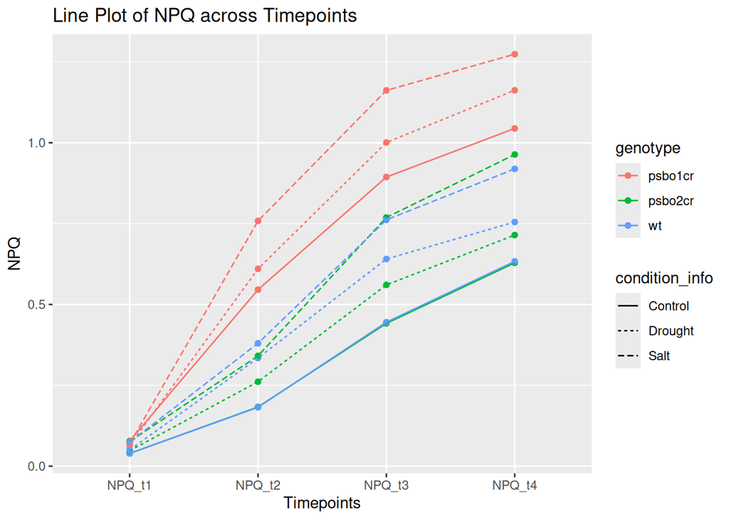

```r
# Do a line plot for NPQ columns with the different timepoints measured

# First, it looks like the NPQ columns have a lot of NA values. So, same as before, we'll remove rows with NAs.
pD_clean_2 <- pD_clean %>%
  filter(!is.na(NPQ_t1), !is.na(NPQ_t2), !is.na(NPQ_t3), !is.na(NPQ_t4))

# Group by genotype and condition_info (this means that your new dataframe will have columns with genotype and condition_info)
# Next use the summarise function to take the mean of the NPQ timepoint values for each of the 9 genotype-condition_info groups
NPQ_summary <- pD_clean_2 %>% group_by(condition_info, genotype) %>%
  summarise(across(c(NPQ_t1, NPQ_t2, NPQ_t3, NPQ_t4), mean))

# Make sure you view the output NPQ_summary dataframe to see what it looks like!

# Reshape the data to "long format" so that there is one column summarizing all 4 NPQ timepoints
NPQ_summary_long <- NPQ_summary %>%
  pivot_longer(cols = c(NPQ_t1, NPQ_t2, NPQ_t3, NPQ_t4), names_to = "Timepoint", values_to = "NPQ")

# Create a new column with condition and genotype concatenated so that we can have 9 unique groups
NPQ_summary_long_2 <- NPQ_summary_long %>%
  unite(col = condition_genotype, condition_info, genotype, sep = "_", remove = F)

# Create the line plot
p7 <- ggplot(NPQ_summary_long_2, aes(x = Timepoint, y = NPQ, linetype = condition_info, color = genotype)) +
  geom_point() +
  geom_line(aes(group = condition_genotype)) +
  labs(x = "Timepoints", y = "NPQ", title = "Line Plot of NPQ across Timepoints")
p7
```

**Extra exercise:** An alternative way to visualize the above data is using a heatmap. We have not gone over these before, however, there is some information on making heatmaps in ggplot available [here](https://r-graph-gallery.com/79-levelplot-with-ggplot2.html).

Hints: You can start from the same dataframe that you used for the line plot above, along with the `geom_tile()` function to make the heatmap. We suggest using `Timepoint` on the x-axis and `genotype` on the y axis, coloring by `NPQ` in the `geom_tile()` function. You can also use the `facet_wrap()` function with the `condition_info` column to split the plot by the various conditions!

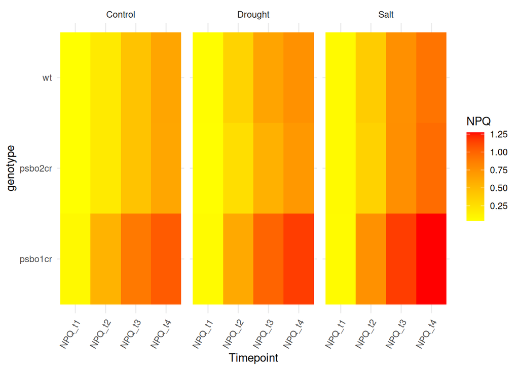

```r
p7_heatmap <- ggplot(NPQ_summary_long_2, aes(x = Timepoint, y = genotype)) +
  geom_tile(aes(fill = NPQ)) +
  scale_fill_gradient(low = "yellow", high = "red") +
  facet_wrap(~condition_info) +
  theme_minimal() +
  theme(axis.text.x = element_text(angle = 60, hjust=1)) #rotate X-axis labels to avoid them overlapping.
p7_heatmap
```

The heatmap’s interpretation is almost identical to the lineplot, where we observe the NPQ value increasing by timepoint across the conditions. It also allows a more straightforward comparison between geotypes so that we can observe that the wt and *psbo2cr* genotypes are similar while the *psbo1cr* genotype has higher NPQ values.

**Treasure hunt:** Import the file `XA53_experiment.txt` from your working folder and plot the data. Can you find something interesting in the data? Let us know if you find an interesting pattern.

Hint: This file is tab-separated. Use the `read.table()` function with arguments `sep = "\t"` (separator of the fields is tabulator) and `header = T` (to use the first line of the file as column names).

```r
# Read the data
exp <- read.table(file = "XA53_experiment.txt", sep = "\t", header = T)

# Base R solution
plot(exp$cell.width, exp$cell.height, col = as.factor(paste(exp$genotype, exp$treatment)))

# ggplot solution
# ploting width againts height and coloring according to treatment does not show anything
ggplot(data = exp, aes(x = cell.width, y = cell.height, col = treatment)) +
  geom_point()
# doing the same and coloring according to genotype shows something :-)
ggplot(data = exp, aes(x = cell.width, y = cell.height, col = genotype)) +
  geom_point()
```

[output not shown]

### 5. End

Thank you for going through this tutorial. If you have any comments or suggestions for improvement, you can write to Milos (duchmil[at]gmail.com) or tell us in person.